# Project: Investigate the TMDb Movie Dataset

- Introduction
- Data Wrangling
- Exploratory Data Analysis
- Conclusions

## Introduction

I have chosen to examine the TMDb Movie Dataset from Kaggle. (https://www.kaggle.com/tmdb/tmdb-movie-metadata)

This dataset contains information about appr. 10 thousand movies. It consists of 21 columns such as id, imdb_id, title, popularity, budget, revenue, cast, director, production companies, ratings, homepage, genres, release_date, and average vote.

I decided to ask questions about financials (budget, revenue, and profit) and feedback (popularity and average vote).

#### Questions asked:

1. Which five movies had the most and the least profit?
2. How has the average budget, revenue and profit of the movies changed over the years?
3. What is the correlation between the columns?
4. Does the budget correlate with the revenue?
5. Or does the budget correlate with the popularity?
6. Does the revenue correlate with the average vote?

```python
# import statements
import numpy as np
import pandas as pd
import matplotlib.pyplot as plt
import seaborn as sns
from datetime import datetime

# 'magic word'
#  More info: http://ipython.readthedocs.io/en/stable/interactive/magics.html
%matplotlib inline
```

## Data Wrangling

### First step: Load the data and examine it

```python
# Load the data and print out a few lines

movies = pd.read_csv('tmdb-movies.csv')
movies.head()

# jupyter notebook useful shortcuts:
# B : add new code cell
# X : delete cell
# M : Markdown cell
```

|  | id | imdb_id | popularity | budget | revenue | original_title | cast | homepage | director | tagline | ... | overview | runtime | genres | production_companies | release_date | vote_count | vote_average | release_year | budget_adj | revenue_adj |
| --- | --- | --- | --- | --- | --- | --- | --- | --- | --- | --- | --- | --- | --- | --- | --- | --- | --- | --- | --- | --- | --- |
| 0 | 135397 | tt0369610 | 32.985763 | 150000000 | 1513528810 | Jurassic World | Chris Pratt\|Bryce Dallas Howard\|Irrfan Khan\|Vi... | http://www.jurassicworld.com/ | Colin Trevorrow | The park is open. | ... | Twenty-two years after the events of Jurassic ... | 124 | Action\|Adventure\|Science Fiction\|Thriller | Universal Studios\|Amblin Entertainment\|Legenda... | 6/9/15 | 5562 | 6.5 | 2015 | 1.379999e+08 | 1.392446e+09 |
| 1 | 76341 | tt1392190 | 28.419936 | 150000000 | 378436354 | Mad Max: Fury Road | Tom Hardy\|Charlize Theron\|Hugh Keays-Byrne\|Nic... | http://www.madmaxmovie.com/ | George Miller | What a Lovely Day. | ... | An apocalyptic story set in the furthest reach... | 120 | Action\|Adventure\|Science Fiction\|Thriller | Village Roadshow Pictures\|Kennedy Miller Produ... | 5/13/15 | 6185 | 7.1 | 2015 | 1.379999e+08 | 3.481613e+08 |
| 2 | 262500 | tt2908446 | 13.112507 | 110000000 | 295238201 | Insurgent | Shailene Woodley\|Theo James\|Kate Winslet\|Ansel... | http://www.thedivergentseries.movie/#insurgent | Robert Schwentke | One Choice Can Destroy You | ... | Beatrice Prior must confront her inner demons ... | 119 | Adventure\|Science Fiction\|Thriller | Summit Entertainment\|Mandeville Films\|Red Wago... | 3/18/15 | 2480 | 6.3 | 2015 | 1.012000e+08 | 2.716190e+08 |
| 3 | 140607 | tt2488496 | 11.173104 | 200000000 | 2068178225 | Star Wars: The Force Awakens | Harrison Ford\|Mark Hamill\|Carrie Fisher\|Adam D... | http://www.starwars.com/films/star-wars-episod... | J.J. Abrams | Every generation has a story. | ... | Thirty years after defeating the Galactic Empi... | 136 | Action\|Adventure\|Science Fiction\|Fantasy | Lucasfilm\|Truenorth Productions\|Bad Robot | 12/15/15 | 5292 | 7.5 | 2015 | 1.839999e+08 | 1.902723e+09 |
| 4 | 168259 | tt2820852 | 9.335014 | 190000000 | 1506249360 | Furious 7 | Vin Diesel\|Paul Walker\|Jason Statham\|Michelle ... | http://www.furious7.com/ | James Wan | Vengeance Hits Home | ... | Deckard Shaw seeks revenge against Dominic Tor... | 137 | Action\|Crime\|Thriller | Universal Pictures\|Original Film\|Media Rights ... | 4/1/15 | 2947 | 7.3 | 2015 | 1.747999e+08 | 1.385749e+09 |

5 rows × 21 columns

```python
movies.shape
```

```
(10866, 21)
```

### Second step: Data cleaning

### The Data Structure

**After** we find out the questions we want to ask, we should clean the dataset. After, because the actual cleaning steps depend on what we want to do with the data. We need to check the dataset for missing or duplicate values, data inconsistency, inadequate datatypes and insufficent data. It is also useful to reduce the size of the dataset for the necessary columns to make the code more efficient.

#### A. Missing values:

```python
#  inspect data types and look for instances of missing or possibly errant data.

movies.info()
```

```
<class 'pandas.core.frame.DataFrame'>
RangeIndex: 10866 entries, 0 to 10865
Data columns (total 21 columns):
id                      10866 non-null int64
imdb_id                 10856 non-null object
popularity              10866 non-null float64
budget                  10866 non-null int64
revenue                 10866 non-null int64
original_title          10866 non-null object
cast                    10790 non-null object
homepage                2936 non-null object
director                10822 non-null object
tagline                 8042 non-null object
keywords                9373 non-null object
overview                10862 non-null object
runtime                 10866 non-null int64
genres                  10843 non-null object
production_companies    9836 non-null object
release_date            10866 non-null object
vote_count              10866 non-null int64
vote_average            10866 non-null float64
release_year            10866 non-null int64
budget_adj              10866 non-null float64
revenue_adj             10866 non-null float64
dtypes: float64(4), int64(6), object(11)
memory usage: 1.7+ MB
```

We can see missing values in the imdb_id, cast, homepage, director, tagline, keywords, overview, genres and production_companies columns.

```python
clean_movies = movies

# drop those columns that contains lot of missing values and we don't use
clean_movies.drop(['cast', 'homepage', 'director', 'tagline', 'keywords', 'overview', 'genres', 'production_companies', 'budget_adj', 'revenue_adj'],axis=1, inplace=True)
```

```python
# view missing value count for each feature
clean_movies.isnull().sum()
```

```
id                 0
imdb_id           10
popularity         0
budget             0
revenue            0
original_title     0
runtime            0
release_date       0
vote_count         0
vote_average       0
release_year       0
dtype: int64
```

```python
# drop rows with any null values
clean_movies.dropna(inplace=True)
```

#### B. Duplicates:

```python
# check for duplicates in the dataset
sum(clean_movies.duplicated())
```

```
1
```

```python
# let's check the duplicated value
clean_movies[clean_movies.duplicated()]
```

|  | id | imdb_id | popularity | budget | revenue | original_title | runtime | release_date | vote_count | vote_average | release_year |
| --- | --- | --- | --- | --- | --- | --- | --- | --- | --- | --- | --- |
| 2090 | 42194 | tt0411951 | 0.59643 | 30000000 | 967000 | TEKKEN | 92 | 3/20/10 | 110 | 5.0 | 2010 |

```python
# remove the duplicated value
clean_movies.drop_duplicates(inplace=True)
```

#### C. Inadequate datatypes:

```python
# the datatype of the release_date is 'object' which is not appropriate
# check its type

type(clean_movies.release_date[0])
```

```
str
```

```python
# convert it to datetime type
clean_movies.release_date = pd.to_datetime(clean_movies['release_date'])
```

```python
# let's check again
clean_movies.head()
```

|  | id | imdb_id | popularity | budget | revenue | original_title | runtime | release_date | vote_count | vote_average | release_year |
| --- | --- | --- | --- | --- | --- | --- | --- | --- | --- | --- | --- |
| 0 | 135397 | tt0369610 | 32.985763 | 150000000 | 1513528810 | Jurassic World | 124 | 2015-06-09 | 5562 | 6.5 | 2015 |
| 1 | 76341 | tt1392190 | 28.419936 | 150000000 | 378436354 | Mad Max: Fury Road | 120 | 2015-05-13 | 6185 | 7.1 | 2015 |
| 2 | 262500 | tt2908446 | 13.112507 | 110000000 | 295238201 | Insurgent | 119 | 2015-03-18 | 2480 | 6.3 | 2015 |
| 3 | 140607 | tt2488496 | 11.173104 | 200000000 | 2068178225 | Star Wars: The Force Awakens | 136 | 2015-12-15 | 5292 | 7.5 | 2015 |
| 4 | 168259 | tt2820852 | 9.335014 | 190000000 | 1506249360 | Furious 7 | 137 | 2015-04-01 | 2947 | 7.3 | 2015 |

```python
# let's examine again
clean_movies.info()
```

```
<class 'pandas.core.frame.DataFrame'>
Int64Index: 10855 entries, 0 to 10865
Data columns (total 11 columns):
id                10855 non-null int64
imdb_id           10855 non-null object
popularity        10855 non-null float64
budget            10855 non-null int64
revenue           10855 non-null int64
original_title    10855 non-null object
runtime           10855 non-null int64
release_date      10855 non-null datetime64[ns]
vote_count        10855 non-null int64
vote_average      10855 non-null float64
release_year      10855 non-null int64
dtypes: datetime64[ns](1), float64(2), int64(6), object(2)
memory usage: 1.3+ MB
```

#### D. Data inconsistency:

```python
clean_movies.describe()
```

|  | id | popularity | budget | revenue | runtime | vote_count | vote_average | release_year |
| --- | --- | --- | --- | --- | --- | --- | --- | --- |
| count | 10855.000000 | 10855.000000 | 1.085500e+04 | 1.085500e+04 | 10855.000000 | 10855.000000 | 10855.000000 | 10855.000000 |
| mean | 65959.191617 | 0.646832 | 1.463776e+07 | 3.986359e+07 | 102.105205 | 217.584155 | 5.973865 | 2001.313128 |
| std | 92018.246342 | 1.000591 | 3.092533e+07 | 1.170559e+08 | 31.348734 | 575.877532 | 0.934604 | 12.815672 |
| min | 5.000000 | 0.000065 | 0.000000e+00 | 0.000000e+00 | 0.000000 | 10.000000 | 1.500000 | 1960.000000 |
| 25% | 10591.500000 | 0.207733 | 0.000000e+00 | 0.000000e+00 | 90.000000 | 17.000000 | 5.400000 | 1995.000000 |
| 50% | 20618.000000 | 0.383998 | 0.000000e+00 | 0.000000e+00 | 99.000000 | 38.000000 | 6.000000 | 2006.000000 |
| 75% | 75393.500000 | 0.714446 | 1.500000e+07 | 2.404727e+07 | 111.000000 | 146.000000 | 6.600000 | 2011.000000 |
| max | 417859.000000 | 32.985763 | 4.250000e+08 | 2.781506e+09 | 900.000000 | 9767.000000 | 9.200000 | 2015.000000 |

#### Basic statements:

1. The dataset contains data about approximately 10.000 film. (or 10.855 exactly after cleaning.)
2. The popularity goes approximately from 0 to 33. The average popularity is 0.65.
3. The vote_average goes from 1.5 to 9.2, and the majority fall between 5.4 and 6.6.
4. The budget goes from 0 to 4e+08.
5. The revenue goes from 0 to 2e+09.
6. The release year goes from 1960 to 2015.

#### Conclusion:

Zeros in the budget and the revenue columns don't look valid value. I need to handle those values. Since both the median of the 'budget' and the 'revenue' is zero, then more than half of the dataset contains incorrect financial data. We can substitute them with the median or mean, but this would distort the data significantly, so I decided to delete them. Otherwise, the dataset looks clean enough for my tasks.

```python
# let's check the values with zero budget
clean_movies[clean_movies['budget'] == 0]
```

|  | id | imdb_id | popularity | budget | revenue | original_title | runtime | release_date | vote_count | vote_average | release_year |
| --- | --- | --- | --- | --- | --- | --- | --- | --- | --- | --- | --- |
| 30 | 280996 | tt3168230 | 3.927333 | 0 | 29355203 | Mr. Holmes | 103 | 2015-06-19 | 425 | 6.4 | 2015 |
| 36 | 339527 | tt1291570 | 3.358321 | 0 | 22354572 | Solace | 101 | 2015-09-03 | 474 | 6.2 | 2015 |
| 72 | 284289 | tt2911668 | 2.272044 | 0 | 45895 | Beyond the Reach | 95 | 2015-04-17 | 81 | 5.5 | 2015 |
| 74 | 347096 | tt3478232 | 2.165433 | 0 | 0 | Mythica: The Darkspore | 108 | 2015-06-24 | 27 | 5.1 | 2015 |
| 75 | 308369 | tt2582496 | 2.141506 | 0 | 0 | Me and Earl and the Dying Girl | 105 | 2015-06-12 | 569 | 7.7 | 2015 |
| ... | ... | ... | ... | ... | ... | ... | ... | ... | ... | ... | ... |
| 10860 | 5060 | tt0060214 | 0.087034 | 0 | 0 | Carry On Screaming! | 87 | 2066-05-20 | 13 | 7.0 | 1966 |
| 10861 | 21 | tt0060371 | 0.080598 | 0 | 0 | The Endless Summer | 95 | 2066-06-15 | 11 | 7.4 | 1966 |
| 10862 | 20379 | tt0060472 | 0.065543 | 0 | 0 | Grand Prix | 176 | 2066-12-21 | 20 | 5.7 | 1966 |
| 10863 | 39768 | tt0060161 | 0.065141 | 0 | 0 | Beregis Avtomobilya | 94 | 2066-01-01 | 11 | 6.5 | 1966 |
| 10864 | 21449 | tt0061177 | 0.064317 | 0 | 0 | What's Up, Tiger Lily? | 80 | 2066-11-02 | 22 | 5.4 | 1966 |

5687 rows × 11 columns

```python
# create a list of revenue and budget columns
column_list=['budget', 'revenue']

# replace all the values from '0' to NAN in these columns in the dataset
clean_movies[column_list] = clean_movies[column_list].replace(0, np.NAN)

# remove the rows with NaN value
clean_movies.dropna(subset = column_list, inplace = True)
```

```python
# let's check how many data left
clean_movies.shape
```

```
(3854, 11)
```

#### E. Insufficent data:

We don't have profit values in the dataset, but we can aggregate it from the budget and the revenue column. I'm going to add a new column to the dataset represents the total profit of the movie which is calculated by subtracting the budget from the revenue.

```python
# insert the new 'profit' column
clean_movies['profit'] = clean_movies['revenue']-clean_movies['budget']

# previewing the changes
clean_movies.head()
```

|  | id | imdb_id | popularity | budget | revenue | original_title | runtime | release_date | vote_count | vote_average | release_year | profit |
| --- | --- | --- | --- | --- | --- | --- | --- | --- | --- | --- | --- | --- |
| 0 | 135397 | tt0369610 | 32.985763 | 150000000.0 | 1.513529e+09 | Jurassic World | 124 | 2015-06-09 | 5562 | 6.5 | 2015 | 1.363529e+09 |
| 1 | 76341 | tt1392190 | 28.419936 | 150000000.0 | 3.784364e+08 | Mad Max: Fury Road | 120 | 2015-05-13 | 6185 | 7.1 | 2015 | 2.284364e+08 |
| 2 | 262500 | tt2908446 | 13.112507 | 110000000.0 | 2.952382e+08 | Insurgent | 119 | 2015-03-18 | 2480 | 6.3 | 2015 | 1.852382e+08 |
| 3 | 140607 | tt2488496 | 11.173104 | 200000000.0 | 2.068178e+09 | Star Wars: The Force Awakens | 136 | 2015-12-15 | 5292 | 7.5 | 2015 | 1.868178e+09 |
| 4 | 168259 | tt2820852 | 9.335014 | 190000000.0 | 1.506249e+09 | Furious 7 | 137 | 2015-04-01 | 2947 | 7.3 | 2015 | 1.316249e+09 |

### Summerize the cleaning process:

- I removed the columns 'cast', 'homepage', 'director', 'tagline', 'keywords', 'overview', 'genres', 'production_companies', 'budget_adj', 'revenue_adj' to improve performance and eliminate lot of missing values.
- I cleaned the left missing values
- I removed the duplicated value
- I converted release_date from string to datatype.
- I removed the 0 values from the budget and the revenue.
- I inserted a new aggregated column: 'profit'

## Exploratory Data Analysis

### Quick statistics first:

```python
# check the basic statistics of the cleaned data
clean_movies.describe()
```

|  | id | popularity | budget | revenue | runtime | vote_count | vote_average | release_year | profit |
| --- | --- | --- | --- | --- | --- | --- | --- | --- | --- |
| count | 3854.000000 | 3854.000000 | 3.854000e+03 | 3.854000e+03 | 3854.000000 | 3854.000000 | 3854.000000 | 3854.000000 | 3.854000e+03 |
| mean | 39888.185262 | 1.191554 | 3.720370e+07 | 1.076866e+08 | 109.220291 | 527.720291 | 6.168163 | 2001.261028 | 7.048292e+07 |
| std | 67222.527399 | 1.475162 | 4.220822e+07 | 1.765393e+08 | 19.922820 | 879.956821 | 0.794920 | 11.282575 | 1.506195e+08 |
| min | 5.000000 | 0.001117 | 1.000000e+00 | 2.000000e+00 | 15.000000 | 10.000000 | 2.200000 | 1960.000000 | -4.139124e+08 |
| 25% | 6073.500000 | 0.462368 | 1.000000e+07 | 1.360003e+07 | 95.000000 | 71.000000 | 5.700000 | 1995.000000 | -1.321535e+06 |
| 50% | 11321.500000 | 0.797511 | 2.400000e+07 | 4.480000e+07 | 106.000000 | 204.000000 | 6.200000 | 2004.000000 | 2.002019e+07 |
| 75% | 38573.250000 | 1.368324 | 5.000000e+07 | 1.242125e+08 | 119.000000 | 580.000000 | 6.700000 | 2010.000000 | 8.170331e+07 |
| max | 417859.000000 | 32.985763 | 4.250000e+08 | 2.781506e+09 | 338.000000 | 9767.000000 | 8.400000 | 2015.000000 | 2.544506e+09 |

```
array([[<matplotlib.axes._subplots.AxesSubplot object at 0x0000016D1605D860>,
      dtype=object)
```

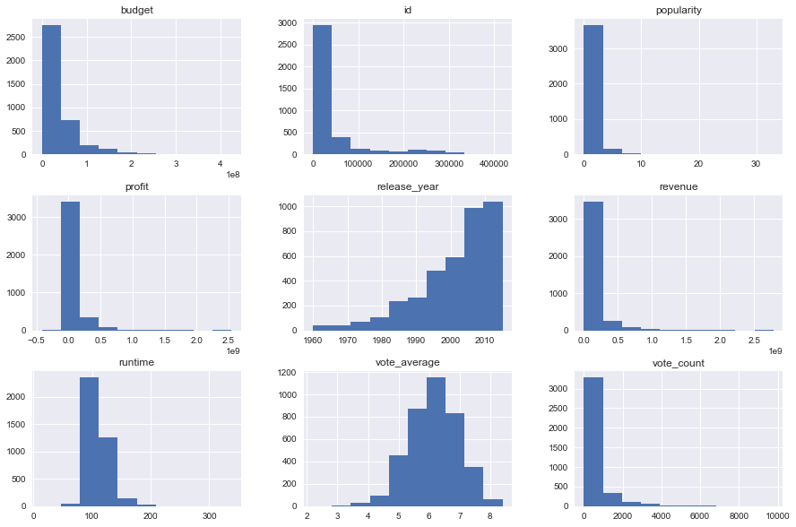

```python
# print the distributions of the data in each columns
clean_movies.hist(figsize=(15,10))
```

### Research Question 1: Which five movies had the most and the least profit?

```python
# sort the data by profit in decreasing order
clean_movies.sort_values(['profit'], axis=0, ascending=False, inplace=True)
```

```python
# display the 5 movies with the most profit
clean_movies.head()
```

|  | id | imdb_id | popularity | budget | revenue | original_title | runtime | release_date | vote_count | vote_average | release_year | profit |
| --- | --- | --- | --- | --- | --- | --- | --- | --- | --- | --- | --- | --- |
| 1386 | 19995 | tt0499549 | 9.432768 | 237000000.0 | 2.781506e+09 | Avatar | 162 | 2009-12-10 | 8458 | 7.1 | 2009 | 2.544506e+09 |
| 3 | 140607 | tt2488496 | 11.173104 | 200000000.0 | 2.068178e+09 | Star Wars: The Force Awakens | 136 | 2015-12-15 | 5292 | 7.5 | 2015 | 1.868178e+09 |
| 5231 | 597 | tt0120338 | 4.355219 | 200000000.0 | 1.845034e+09 | Titanic | 194 | 1997-11-18 | 4654 | 7.3 | 1997 | 1.645034e+09 |
| 0 | 135397 | tt0369610 | 32.985763 | 150000000.0 | 1.513529e+09 | Jurassic World | 124 | 2015-06-09 | 5562 | 6.5 | 2015 | 1.363529e+09 |
| 4 | 168259 | tt2820852 | 9.335014 | 190000000.0 | 1.506249e+09 | Furious 7 | 137 | 2015-04-01 | 2947 | 7.3 | 2015 | 1.316249e+09 |

```python
# display the 5 movies with the least profit
clean_movies.tail()
```

|  | id | imdb_id | popularity | budget | revenue | original_title | runtime | release_date | vote_count | vote_average | release_year | profit |
| --- | --- | --- | --- | --- | --- | --- | --- | --- | --- | --- | --- | --- |
| 4970 | 10009 | tt0328880 | 1.653031 | 100000000.0 | 250.0 | Brother Bear | 85 | 2003-10-20 | 753 | 6.8 | 2003 | -99999750.0 |
| 3484 | 50321 | tt1305591 | 0.921653 | 150000000.0 | 38992758.0 | Mars Needs Moms | 88 | 2011-03-09 | 129 | 5.5 | 2011 | -111007242.0 |
| 7031 | 10733 | tt0318974 | 0.948560 | 145000000.0 | 25819961.0 | The Alamo | 137 | 2004-04-07 | 60 | 5.9 | 2004 | -119180039.0 |
| 5508 | 57201 | tt1210819 | 1.214510 | 255000000.0 | 89289910.0 | The Lone Ranger | 149 | 2013-07-03 | 1607 | 6.0 | 2013 | -165710090.0 |
| 2244 | 46528 | tt1032751 | 0.250540 | 425000000.0 | 11087569.0 | The Warrior's Way | 100 | 2010-12-02 | 74 | 6.4 | 2010 | -413912431.0 |

### Research Question 2: How has the average budget, revenue and profit of the movies changed over the years?

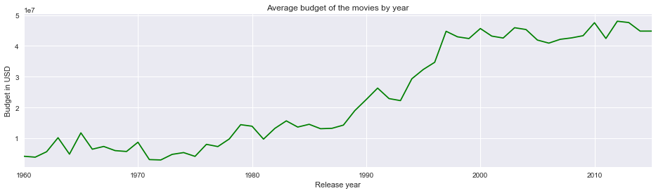

```python
clean_movies.groupby('release_year').budget.mean().plot(kind='line', figsize=(16,4), title='Average budget of the movies by year', color='green')
plt.xlabel("Release year")
plt.ylabel('Budget in USD')
```

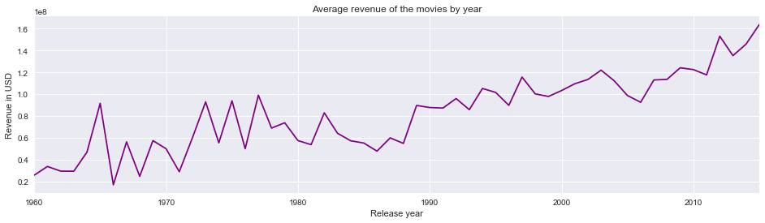

```python
#clean_movies.groupby('release_year').revenue.mean().plot(kind='line', figsize=(16,4), title="Revenue", color="purple")
clean_movies.groupby('release_year').revenue.mean().plot(kind='line', figsize=(16,4), title='Average revenue of the movies by year', color='purple')
plt.xlabel("Release year")
plt.ylabel('Revenue in USD')
```

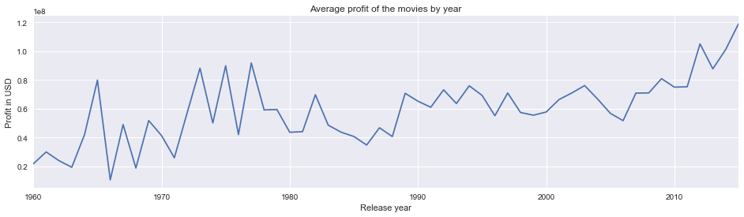

```python
#clean_movies.groupby('release_year').profit.mean().plot(kind='line', figsize=(16,4), title='Profit of the movies by year')
clean_movies.groupby('release_year').profit.mean().plot(kind='line', figsize=(16,4), title='Average profit of the movies by year')
plt.xlabel("Release year")
plt.ylabel('Profit in USD')
```

### Answer:

We can see two trends in the average budget. From 1960 to 1997 the average budget is increasing, and from 1997 to 2015 it is quite constant. The average revenue and profit is increasing.

### Research Question 3 : What is the correlation between the columns?

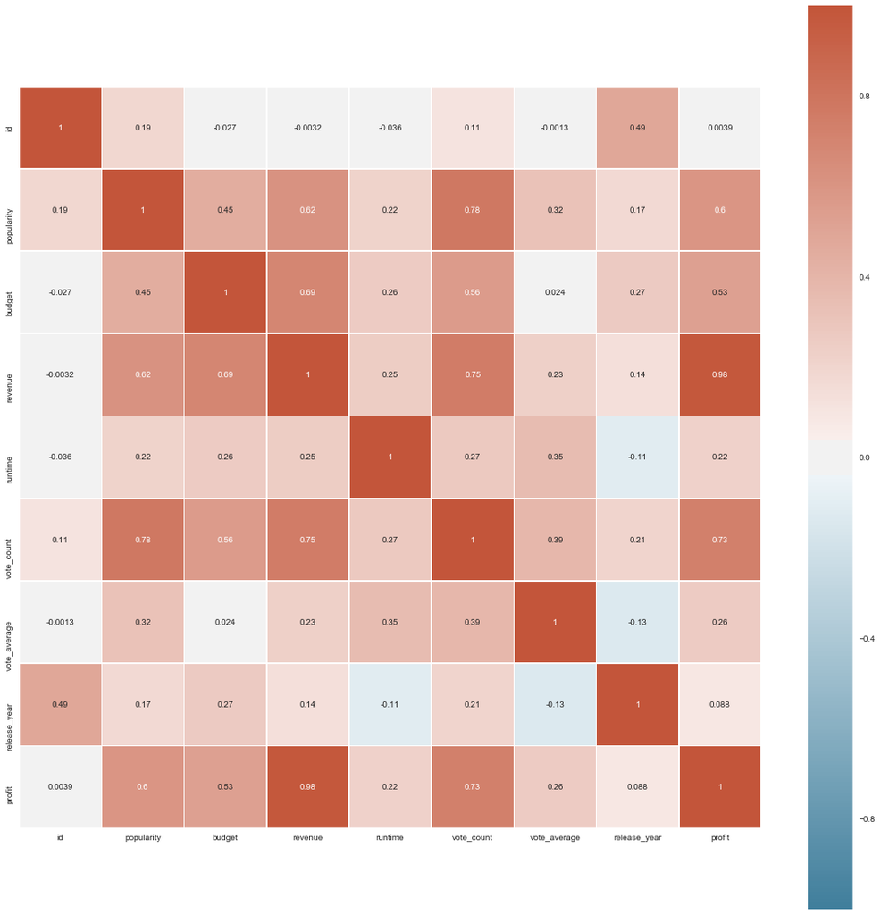

```python
# Plotting a correlation matrix
# let's check the correlation between the columns and draw it with seaborn heatmap function

# Compute the correlation matrix
corr = clean_movies.corr()

# Set up the matplotlib figure
f, ax = plt.subplots(figsize=(20, 20))

# Generate a custom diverging colormap
cmap = sns.diverging_palette(230, 20, as_cmap=True)

# Draw the heatmap
#?sns.heatmap
sns.heatmap(corr, cmap=cmap, center=0, square=True, annot=True, linewidths=.5)
```

### Answer:

- A correlation matrix is “square”, with the same variables shown in the rows and columns. The line of 1-s going from the top left to the bottom right is the main diagonal, which shows that each variable always perfectly correlates with itself. This matrix is symmetrical, with the same correlation is shown above the main diagonal being a mirror image of those below the main diagonal.
- White cell or 0 value means they are not correlated. (like id and vote_average: Correlation coefficient: -0.0013)
- Red means they are positively correlated (like every columns to itself and profit with the revenue. Correlation coefficient: 0.98)
- And blue means they are negatively correlated. We can't see strong negative correlation here. There are only lightblues like runtime with release_year which is so weak negative correlation that close to independent. (Correlation coefficient: -0.11)

### Research Question 4: Does the budget correlate with the revenue?

### Answer:

Yes, it is positively correlated as we can see from the above, it is red or quite redish. Correlation coefficient: 0.69

### Research Question 5: Or does the budget correlate with the popularity?

### Answer:

Yes, it is positively correlated as we can see from the above picture. It is red or quite redish, but weaker correlation than in the above example. Correlation coefficient: 0.45

### Research Question 6: Does the revenue correlate with the average vote?

### Answer:

Well, they have a little positive correlation as we can see from the above, it is a little redish. Correlation coefficient: 0.23

## Conclusions

In this project I examined the TMDb Movie Dataset. I find which five movies had the most and the least profit. 'Avatar' was the first and 'The Warrior's Way' was the last by profitability. I also examined how has the average budget, revenue and profit of the movies changed over the years. I find that from 1960 to 1997 the average budget is increasing, and from 1997 to 2015 it is quite constant. The average revenue and profit is increasing. I examined the correlation between the columns. I draw the heatmap of the collelation matrix. I find that the budget positively correlate with the revenue, the budget also positively correlate with the popularity and the revenue also positively correlate with the average vote a littlebit.